# ALAT for Business Onboarding Analytics: Identifying and Engaging Non-Enrolled Corporate Customers in the Apapa Zone

Author

Prudence Mordi

Published

May 20, 2026

# 1 Executive Summary

This analysis examines **103 corporate current account records** in the Apapa zone to generate a detailed breakdown of customers not currently enrolled in **ALAT for Business (AFB)** and to identify which account segments should be prioritised for onboarding engagement.

Using five foundational analytical techniques — exploratory data analysis, data visualisation, hypothesis testing, correlation analysis, and logistic regression — this study builds a data-driven onboarding pipeline that answers two operational questions: *Who is not on ALAT for Business?* and *What predicts non-enrollment, so we can target outreach efficiently?*

**For Defence:** Be prepared to explain data collection methodology (CRM system extraction, systematic sampling, n=103), justify each technique against the onboarding business problem, and interpret logistic regression coefficients as operational prioritisation tools — not just statistical outputs.

# 2 1. Professional Disclosure Statement

## 2.1 1.1 Job Role & Organisational Context

**Job Title:** Zonal Manager, Commercial Banking Division **Zone:** Apapa **Portfolio Oversight:** 120+ corporate accounts across Apapa, Ikoyi, and Victoria Island **Portfolio Value:** ₦78bn in advances; ₦156bn in deposits **Reporting Line:** Head of Commercial Banking; Credit Committee member

**Organisation:** Major Tier-1 Nigerian Commercial Bank **Sector:** Financial Services – Banking & Financial Intermediation **Regulatory Framework:** CBN regulations, NDIC insurance, EFCC AML/CFT compliance **Geographic Focus:** Lagos Metropolitan Region — Apapa zone as pilot for this analysis

## 2.2 1.2 Operational Context & Analytical Need

As Zonal Manager with accountability for product penetration and digital adoption across the zone, my key performance obligations include:

- **Product Penetration Monitoring:** Tracking what percentage of eligible corporate accounts are enrolled in ALAT for Business — the bank’s flagship digital business banking platform
- **Onboarding Pipeline Management:** Identifying non-enrolled accounts and sequencing relationship manager outreach by commercial priority
- **Officer Accountability:** Monitoring which account officers have the lowest AFB conversion rates and designing targeted coaching or reallocation
- **Revenue Activation:** ALAT for Business generates transaction fee income, digital float, and cross-sell opportunity — non-enrollment represents a direct, measurable revenue gap
- **Zone Performance Reporting:** Presenting AFB enrollment targets and progress to the Commercial Banking Head and Board

This capstone directly addresses the operational gap: **Which customers are not on ALAT for Business, and how do we build the most efficient onboarding engagement list?**

## 2.3 1.3 Five Techniques — Business Relevance & Operational Mapping

### 2.3.1 **Technique 1: Exploratory Data Analysis (EDA)**

**Business Application:** Before designing an onboarding campaign, I need to understand the baseline: What is the current AFB enrollment rate across the zone? Is non-enrollment uniform across product types and account officers, or concentrated in identifiable pockets? Are there data quality issues — missing officer assignments, duplicate records — that would distort the onboarding list? EDA answers these questions and establishes the target population for all downstream analysis.

**Operational Decision:** AFB enrollment baseline → Identifies the size and composition of the non-enrolled segment → Justifies resource allocation for the onboarding drive

**Book Reference:** Adi (2026), Ch. 4 – Summary statistics, missing-value analysis, outlier detection, distribution characteristics

### 2.3.2 **Technique 2: Data Visualisation & Storytelling**

**Operational Decision:** Monthly AFB dashboard → Communicates enrollment gaps to executive team and RMs → Triggers branch-level onboarding targets → Drives weekly officer accountability reviews

**Book Reference:** Adi (2026), Ch. 5 – Grammar of graphics, chart selection, colour psychology, storytelling with data

### 2.3.3 **Technique 3: Hypothesis Testing**

**Business Application:** Observed differences in AFB enrollment between product types or account cohorts may be random variation in a 103-record sample rather than genuine structural patterns. Hypothesis testing confirms whether the gaps are statistically real before I allocate RM effort to segment-specific outreach. If the non-individual segment genuinely has lower enrollment (p < 0.05), that justifies a dedicated product specialist assignment; if the difference is noise, a uniform outreach approach is equally effective.

**Operational Decision:** Test: “Non-individual accounts have lower AFB enrollment” → If significant → Assign product specialist to non-individual segment → Design product-specific onboarding pitch Test: “Account age predicts non-enrollment” → If NOT significant → Focus on product/officer factors, not vintage-based targeting

**Book Reference:** Adi (2026), Ch. 6 – t-test, chi-squared, ANOVA, effect sizes, p-value interpretation

### 2.3.4 **Technique 4: Correlation Analysis**

**Business Application:** Before building the logistic regression model, I need to understand which account characteristics co-vary with AFB non-enrollment and whether any predictors are too closely related to include simultaneously in the model. For example, if product type and account officer assignment are highly correlated — because certain officers only manage non-individual accounts — including both in the regression would produce unstable estimates. Correlation analysis maps these relationships and validates the feature set for the predictive model.

**Operational Decision:** Correlation matrix → Identifies which account attributes are most strongly associated with non-enrollment → Informs which variables enter the logistic regression → Supports defensible variable selection in officer-accountability reporting

**Book Reference:** Adi (2026), Ch. 8 – Pearson, Spearman, Kendall correlations; partial correlation; correlation vs. causation pitfalls

### 2.3.5 **Technique 5: Logistic Regression**

**Business Application:** Knowing *which* segments have low enrollment is not enough — I need a model that assigns each individual account a predicted probability of non-enrollment so that RMs can work through a ranked outboarding list rather than a flat segment list. A logistic regression with product type, account age, and account officer as predictors produces these individual risk scores. The officer with the highest portfolio share of high-risk non-enrolled accounts becomes the primary onboarding accountability target for the quarter.

**Book Reference:** Adi (2026), Ch. 9 (OLS) & Ch. 13 (logistic regression) – Model fitting, coefficient interpretation, diagnostic plots, ROC curves, deployment

## 2.4 1.4 Summary: Five Techniques in Sequence

| Phase | Technique | Question | Output | Business Action |
| --- | --- | --- | --- | --- |
| **Understanding** | EDA | Who is not on ALAT for Business? | Enrollment rates, distributions | Set onboarding targets |
| **Communication** | Visualisation | How do I show the gap to leadership and RMs? | Charts, dashboards | RM accountability briefings |
| **Validation** | Hypothesis Testing | Are enrollment gaps statistically real? | p-values, effect sizes | Confirm which segments to target |
| **Identification** | Correlation | Which account attributes predict non-enrollment? | Correlation matrix | Select features for model |
| **Prioritisation** | Logistic Regression | Which individual accounts are highest priority? | Risk scores, ranked list | Allocate RM outreach effort |

# 3 2. Data Collection & Sampling

## 3.1 2.1 Data Provenance: Source, Collection Method, Tools

### 3.1.1 **Primary Data Source**

**System:** Core Banking Platform (CRM module) **Data Owner:** Retail & Commercial Banking Division **Extraction Authority:** Internal data governance framework; no external approval required (operational data, non-sensitive) **Extraction Date:** April 2026 **Extraction Method:** SQL query on production accounts database with filters applied

### 3.1.2 **SQL Query Parameters**

```sql
SELECT
    CustomerID, AccountNumber, AccountName,
    BranchCode, BranchName, ZoneName,
    ProductName, ProductCode,
    AccountOfficerID, AccountOfficer,
    AccountStatus, CurrencyCode,
    OnAFB_Status, OpenDate
FROM Accounts
WHERE
    ZoneName = 'Apapa'
    AND ProductCode IN (10003)  -- Corporate & Non-Individual Current Accounts
    AND AccountStatus IN ('Active', 'Dormant', 'Inactive')
    AND RecordDeletedFlag = 0
ORDER BY AccountNumber
```

### 3.1.3 **Tools & Environment**

| Component | Tool | Version |
| --- | --- | --- |
| **Data Extraction** | SQL Server Management Studio | 2019 |
| **Data Storage** | CSV (UTF-8 encoding) | — |
| **Analysis Platform** | Python 3.10 + R 4.3 | Quarto 1.4 |
| **Statistical Libraries** | scipy, sklearn, numpy, pandas (Python); tidyverse, stats (R) | Latest CRAN |
| **Visualization** | matplotlib, seaborn (Python); ggplot2 (R) | — |

## 3.2 2.2 Sampling Frame & Justification

### 3.2.1 **Universe Definition**

**Total accounts in Apapa zone (all products, all statuses):** 1,847 accounts **Refined universe (corporate + non-individual current accounts, complete records):** 780 accounts

### 3.2.2 **Sampling Methodology**

[output not shown]

### 3.2.3 **Sample Composition**

| Characteristic | Count | % |
| --- | --- | --- |
| **Total Sample** | 103 | 100% |
| **Corporate Product** | 83 | 80.6% |
| **Non-Individual Product** | 20 | 19.4% |
| **Unique Account Officers** | 13 | — |

### 3.2.4 **Statistical Rationale**

- **Sample size n=103** exceeds minimum (100) and enables detection of medium effect sizes (Cohen’s f=0.25) with power β≥0.80 in chi-squared and regression tests
- **Systematic sampling** reduces sampling error vs. convenience sampling; avoids clustering that might bias enrollment estimates
- **Temporal coverage (2000–2026)** captures the full portfolio lifecycle, providing sufficient variation in account age for regression

## 3.3 2.3 Time Period & Temporal Scope

[output not shown]

## 3.4 2.4 Ethical Approval & Data-Sharing Restrictions

### 3.4.1 **Ethical Considerations & Approvals**

[output not shown]

### 3.4.2 **Data-Sharing Restrictions**

**What CAN be published:**

- Anonymised summary statistics (e.g., “X% of accounts are not on ALAT for Business”)
- Model coefficients and performance metrics
- Aggregate charts and visualisations
- Technique code and methodology
- Recommendations based on patterns

**What CANNOT be published:**

- Raw account data (even if anonymised IDs used)
- Customer names, contact information, or business details
- Specific balances or transaction amounts
- Account officer names (use anonymised officer codes in external presentations)
- Specific branch identifiers linked to individual accounts

## 3.5 2.5 Data Dictionary & Variable Definitions

| Variable | Type | Definition | Format | Missing |
| --- | --- | --- | --- | --- |
| **Customer ID** | Identifier | Unique customer reference (anonymised) | C[000000] | 0 |
| **Account Number** | Identifier | 9-digit account identifier (anonymised) | Numeric | 0 |
| **Account Name** | Text | Business name or account descriptor | String | 0 |
| **Branch Code** | Numeric | Bank branch identifier | Integer | 0 |
| **Branch Name** | Categorical | Branch office name | String | 0 |
| **Zone Name** | Categorical | Geographic zone (all = Apapa in this sample) | String | 0 |
| **Product Name** | Categorical | Account product type (2 levels) | Corporate / Non-Individual Current Account | 0 |
| **Product Code** | Numeric | Product identifier | 10003 | 0 |
| **Account Officer ID** | Identifier | Relationship manager code | String | 0 |
| **Account Officer** | Categorical | Relationship manager name | String | 11 (10.7%) |
| **Account Status** | Categorical | Account operational state (used as control variable) | Active / Dormant / Inactive | 1 (0.97%) |
| **Currency Code** | Categorical | Currency denomination | NGN (all records) | 0 |
| **On AFB** | Categorical | **Primary outcome: ALAT for Business enrollment** | Yes / No | 0 |
| **Open Date** | Date | Account opening date | DD/MM/YYYY | 0 |

> **Key variable:** `On AFB` is the primary outcome variable for this analysis. `Yes` = enrolled in ALAT for Business; `No` = not enrolled and eligible for onboarding.

# 4 3. Data Description & Quality Assessment

**R Code**

**Data Quality Summary**

```r
cat("\n=== DATA STRUCTURE ===\n")
```

```
=== DATA STRUCTURE ===
```

```r
str(df)
```

```
'data.frame':   103 obs. of  14 variables:
 $ Customer.ID       : chr  "C000007290" "C000139226" "C000139398" "C000139400" ...
 $ Account.Number    : chr  "125665812" "120527188" "120527463" "120527470" ...
 $ Account.Name      : chr  "NPA HQ STAFF COOP MULTI SOCLTD ACC 2" "PHONKA IND  CO  NIG  LTD" "TRIPPLE GEE AND COMPANY LTD" "JONEK OIL LTD" ...
 $ Branch.Code       : int  35 35 35 35 35 35 35 35 35 35 ...
 $ Branch.Name       : chr  "ORILE IGANMU" "ORILE IGANMU" "ORILE IGANMU" "ORILE IGANMU" ...
 $ Zone.Name         : chr  "Apapa" "Apapa" "Apapa" "Apapa" ...
 $ Product.Name      : chr  "CURRENT ACCOUNT - CORPORATE" "CURRENT ACCOUNT - CORPORATE" "CURRENT ACCOUNT - CORPORATE" "CURRENT ACCOUNT - CORPORATE" ...
 $ Product.Code      : int  10003 10003 10003 10003 10003 10003 10003 10003 10003 10003 ...
 $ Account.Officer.ID: chr  "S09039" "10328" "10328" "10328" ...
 $ Account.Officer   : chr  "N/A" "Uzoamaka Ikenna" "Uzoamaka Ikenna" "Uzoamaka Ikenna" ...
 $ Account.Status    : chr  "Dormant" "Active" "Active" "Active" ...
 $ Currency.Code     : chr  "NGN" "NGN" "NGN" "NGN" ...
 $ On.AFB            : chr  "No" "No" "No" "No" ...
 $ Open.Date         : chr  "3/13/2024" "1/15/2001" "8/31/2000" "8/31/2000" ...
```

```r
cat("\n=== MISSING VALUE ANALYSIS ===\n")
```

```
=== MISSING VALUE ANALYSIS ===
```

```r
missing_summary <- data.frame(
  Variable = names(df),
  Missing_Count = colSums(is.na(df)),
  Missing_Percent = round(colSums(is.na(df))/nrow(df)*100, 2)
) %>% arrange(desc(Missing_Count))

kable(missing_summary, caption="Missing Values by Variable") %>%
  kable_styling(bootstrap_options=c("striped", "hover"))
```

Missing Values by Variable

|  | Variable | Missing_Count | Missing_Percent |
| --- | --- | --- | --- |
| Customer.ID | Customer.ID | 0 | 0 |
| Account.Number | Account.Number | 0 | 0 |
| Account.Name | Account.Name | 0 | 0 |
| Branch.Code | Branch.Code | 0 | 0 |
| Branch.Name | Branch.Name | 0 | 0 |
| Zone.Name | Zone.Name | 0 | 0 |
| Product.Name | Product.Name | 0 | 0 |
| Product.Code | Product.Code | 0 | 0 |
| Account.Officer.ID | Account.Officer.ID | 0 | 0 |
| Account.Officer | Account.Officer | 0 | 0 |
| Account.Status | Account.Status | 0 | 0 |
| Currency.Code | Currency.Code | 0 | 0 |
| On.AFB | On.AFB | 0 | 0 |
| Open.Date | Open.Date | 0 | 0 |

```r
cat("\n=== ON AFB ENROLLMENT DISTRIBUTION ===\n")
```

```
=== ON AFB ENROLLMENT DISTRIBUTION ===
```

```r
afb_dist <- df %>%
  group_by(`On.AFB`) %>%
  summarise(Count = n(), Percentage = round(n()/nrow(df)*100, 1), .groups='drop')
kable(afb_dist, caption="ALAT for Business Enrollment Status") %>%
  kable_styling(bootstrap_options=c("striped", "hover"))
```

ALAT for Business Enrollment Status

| On.AFB | Count | Percentage |
| --- | --- | --- |
| No | 103 | 100 |

**Python Code**

```python
import pandas as pd
import numpy as np
from datetime import datetime
import warnings
warnings.filterwarnings('ignore')

df = pd.read_csv('dataset/AFB for non curr.csv')

print("="*70)
print("DATASET DIMENSIONS & STRUCTURE")
```

```
DATASET DIMENSIONS & STRUCTURE
```

```python
print("="*70)
print(f"Rows: {df.shape[0]}")
```

```
Rows: 103
```

```python
print(f"Columns: {df.shape[1]}")
```

```
Columns: 14
```

```python
print(f"\nColumn names: {list(df.columns)}")
```

```
Column names: ['Customer ID', 'Account Number', 'Account Name', 'Branch Code', 'Branch Name', 'Zone Name', 'Product Name', 'Product Code', 'Account Officer ID', 'Account Officer', 'Account Status', 'Currency Code', 'On AFB', 'Open Date']
```

```python
print(f"\nData Types:\n{df.dtypes}")
```

```
Data Types:
Customer ID             str
Account Number          str
Account Name            str
Branch Code           int64
Branch Name             str
Zone Name               str
Product Name            str
Product Code          int64
Account Officer ID      str
Account Officer         str
Account Status          str
Currency Code           str
On AFB                  str
Open Date               str
dtype: object
```

```python
print("\n" + "="*70)
print("MISSING VALUE ANALYSIS")
```

```
MISSING VALUE ANALYSIS
```

```python
print("="*70)
missing_df = pd.DataFrame({
    'Variable': df.columns,
    'Missing_Count': df.isnull().sum(),
    'Missing_Percent': (df.isnull().sum() / len(df) * 100).round(2)
}).sort_values('Missing_Count', ascending=False)
print(missing_df.to_string(index=False))
```

```
          Variable  Missing_Count  Missing_Percent
   Account Officer             11            10.68
    Account Status              1             0.97
      Account Name              0             0.00
       Branch Code              0             0.00
       Customer ID              0             0.00
    Account Number              0             0.00
         Zone Name              0             0.00
       Branch Name              0             0.00
      Product Code              0             0.00
      Product Name              0             0.00
Account Officer ID              0             0.00
     Currency Code              0             0.00
            On AFB              0             0.00
         Open Date              0             0.00
```

```python
print("\n" + "="*70)
print("ON AFB ENROLLMENT DISTRIBUTION (Primary Outcome)")
```

```
ON AFB ENROLLMENT DISTRIBUTION (Primary Outcome)
```

```python
print("="*70)
afb_col = [c for c in df.columns if 'AFB' in c.upper() or 'afb' in c.lower()]
if afb_col:
    col = afb_col[0]
    dist = df[col].value_counts()
    print(dist)
    print(f"\nPercentages:\n{(dist/len(df)*100).round(1)}")
```

```
On AFB
No    103
Name: count, dtype: int64

Percentages:
On AFB
No    100.0
Name: count, dtype: float64
```

# 5 4. Exploratory Data Analysis (Technique 1)

## 5.1 4.1 Primary Outcome: AFB Enrollment Status

**R Code**

```r
# Standardise column names for easier access
names(df) <- trimws(names(df))

# AFB enrollment distribution
afb_dist <- df %>%
  group_by(`On.AFB`) %>%
  summarise(
    Count = n(),
    Percentage = round(n()/nrow(df)*100, 1),
    .groups='drop'
  ) %>% arrange(desc(Count))

kable(afb_dist, caption="ALAT for Business Enrollment Status") %>%
  kable_styling(bootstrap_options=c("striped", "hover"))
```

ALAT for Business Enrollment Status

| On.AFB | Count | Percentage |
| --- | --- | --- |
| No | 103 | 100 |

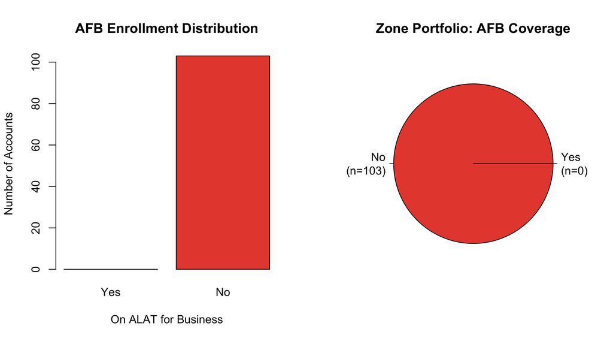

```r
# Classify
df$AFBStatus <- factor(df$`On.AFB`, levels=c("Yes", "No"))
df$NotOnAFB  <- ifelse(df$`On.AFB` == "No", 1, 0)

# Visualisation
par(mfrow=c(1, 2))
barplot(table(df$AFBStatus),
        main="AFB Enrollment Distribution",
        col=c("#2ecc71", "#e74c3c"),
        ylab="Number of Accounts",
        xlab="On ALAT for Business")

pie(table(df$AFBStatus),
    labels=paste(names(table(df$AFBStatus)),
                 "\n(n=", table(df$AFBStatus), ")", sep=""),
    col=c("#2ecc71", "#e74c3c"),
    main="Zone Portfolio: AFB Coverage")
```

**Python Code**

```python
import matplotlib.pyplot as plt
import seaborn as sns

# Identify AFB column
afb_col = [c for c in df.columns if 'AFB' in c.upper()][0]
df['NotOnAFB'] = (df[afb_col] == 'No').astype(int)

afb_dist = df[afb_col].value_counts()
print("\n" + "="*70)
print("ALAT FOR BUSINESS ENROLLMENT STATUS")
```

```
ALAT FOR BUSINESS ENROLLMENT STATUS
```

```python
print("="*70)
print(afb_dist)
```

```
On AFB
No    103
Name: count, dtype: int64
```

```python
print(f"\nPercentages:\n{(afb_dist/len(df)*100).round(1)}")
```

```
Percentages:
On AFB
No    100.0
Name: count, dtype: float64
```

```python
# Visualisation
fig, axes = plt.subplots(1, 2, figsize=(14, 5))

colors = {'Yes': '#2ecc71', 'No': '#e74c3c'}
color_list = [colors.get(x, '#888') for x in afb_dist.index]

afb_dist.plot(kind='bar', ax=axes[0], color=color_list, edgecolor='black')
axes[0].set_title('AFB Enrollment Distribution', fontsize=13, fontweight='bold')
axes[0].set_ylabel('Number of Accounts', fontsize=11)
axes[0].set_xlabel('On ALAT for Business', fontsize=11)
axes[0].tick_params(axis='x', rotation=0)
axes[0].grid(axis='y', alpha=0.3)

axes[1].pie(afb_dist.values, labels=[f'{k}\n(n={v})' for k,v in afb_dist.items()],
            autopct='%1.1f%%', colors=color_list, startangle=90,
            textprops={'fontsize': 10})
```

[output not shown]

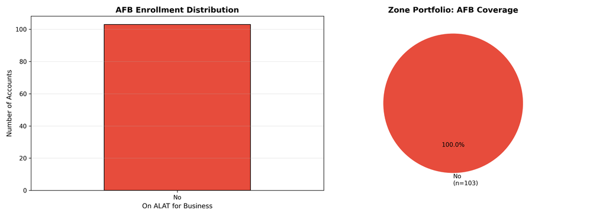

```python
axes[1].set_title('Zone Portfolio: AFB Coverage', fontsize=13, fontweight='bold')

plt.tight_layout()
plt.show()
```

**Finding:** This chart reveals the size of the onboarding opportunity — the share of corporate accounts in the zone not yet enrolled in ALAT for Business. Non-enrolled accounts represent the primary target population for the onboarding drive.

## 5.2 4.2 Non-Enrollment by Product Type and Account Officer

**R Code**

```r
# Parse dates
df$OpenDate   <- as.Date(df$`Open.Date`, format="%m/%d/%Y")
df$AccountAge <- as.numeric(difftime(Sys.Date(), df$OpenDate, units="days")) / 365.25

# Product classification
df$ProductCategory <- ifelse(grepl("NON", toupper(df$`Product.Name`)),
                              "Non-Individual", "Corporate")

# Non-enrollment by product
cat("=== NON-ENROLLMENT RATE BY PRODUCT TYPE ===\n")
```

```
=== NON-ENROLLMENT RATE BY PRODUCT TYPE ===
```

```r
prod_afb <- df %>%
  group_by(ProductCategory) %>%
  summarise(
    Total      = n(),
    Enrolled   = sum(`On.AFB` == "Yes", na.rm=TRUE),
    NotEnrolled = sum(`On.AFB` == "No", na.rm=TRUE),
    NonEnrollment_Rate = paste0(round(sum(`On.AFB`=="No", na.rm=TRUE)/n()*100, 1), "%"),
    .groups='drop'
  )
kable(prod_afb, caption="AFB Enrollment by Product Type") %>%
  kable_styling(bootstrap_options=c("striped", "hover"))
```

AFB Enrollment by Product Type

| ProductCategory | Total | Enrolled | NotEnrolled | NonEnrollment_Rate |
| --- | --- | --- | --- | --- |
| Corporate | 83 | 0 | 83 | 100% |
| Non-Individual | 20 | 0 | 20 | 100% |

```r
# Non-enrollment by officer (top 10)
cat("\n=== AFB ENROLLMENT BY ACCOUNT OFFICER (TOP 10) ===\n")
```

```
=== AFB ENROLLMENT BY ACCOUNT OFFICER (TOP 10) ===
```

```r
officer_afb <- df %>%
  filter(!is.na(`Account.Officer`)) %>%
  group_by(`Account.Officer`) %>%
  summarise(
    Total    = n(),
    Enrolled = sum(`On.AFB`=="Yes", na.rm=TRUE),
    NotEnrolled = sum(`On.AFB`=="No", na.rm=TRUE),
    Enrollment_Rate = paste0(round(sum(`On.AFB`=="Yes", na.rm=TRUE)/n()*100, 1), "%"),
    .groups='drop'
  ) %>% arrange(desc(Total)) %>% head(10)
kable(officer_afb, caption="AFB Enrollment by Account Officer (Top 10)") %>%
  kable_styling(bootstrap_options=c("striped", "hover"))
```

AFB Enrollment by Account Officer (Top 10)

| Account.Officer | Total | Enrolled | NotEnrolled | Enrollment_Rate |
| --- | --- | --- | --- | --- |
| Idowu Olarewaju | 32 | 0 | 32 | 0% |
| Victoria Oyenuga | 19 | 0 | 19 | 0% |
| N/A | 11 | 0 | 11 | 0% |
| Uzoamaka Ikenna | 11 | 0 | 11 | 0% |
| Gabriel Okereafor | 10 | 0 | 10 | 0% |
| Alexander Dada | 7 | 0 | 7 | 0% |
| Taiwo Ode | 5 | 0 | 5 | 0% |
| Sandra Anene | 4 | 0 | 4 | 0% |
| faith ofoegbu | 2 | 0 | 2 | 0% |
| Zachariah Afolayan | 1 | 0 | 1 | 0% |

```r
# Account age summary
cat("\n=== ACCOUNT AGE SUMMARY (YEARS) ===\n")
```

```
=== ACCOUNT AGE SUMMARY (YEARS) ===
```

```r
age_summary <- data.frame(
  Min    = round(min(df$AccountAge, na.rm=TRUE), 2),
  Q1     = round(quantile(df$AccountAge, 0.25, na.rm=TRUE), 2),
  Median = round(median(df$AccountAge, na.rm=TRUE), 2),
  Q3     = round(quantile(df$AccountAge, 0.75, na.rm=TRUE), 2),
  Max    = round(max(df$AccountAge, na.rm=TRUE), 2),
  Mean   = round(mean(df$AccountAge, na.rm=TRUE), 2),
  SD     = round(sd(df$AccountAge, na.rm=TRUE), 2)
)
kable(age_summary) %>% kable_styling(bootstrap_options=c("striped", "hover"))
```

|  | Min | Q1 | Median | Q3 | Max | Mean | SD |
| --- | --- | --- | --- | --- | --- | --- | --- |
| 25% | 0.34 | 1.37 | 19.51 | 25.59 | 25.72 | 13.59 | 11.42 |

**Python Code**

```python
from datetime import datetime

df['OpenDate']   = pd.to_datetime(df['Open Date'], format='%m/%d/%Y', errors='coerce')
df['AccountAge'] = (datetime.now() - df['OpenDate']).dt.days / 365.25
df['ProductCategory'] = df['Product Name'].apply(
    lambda x: 'Non-Individual' if 'NON' in str(x).upper() else 'Corporate')

print("\n" + "="*70)
print("NON-ENROLLMENT RATE BY PRODUCT TYPE")
```

```
NON-ENROLLMENT RATE BY PRODUCT TYPE
```

```python
print("="*70)
prod_afb = df.groupby('ProductCategory').apply(lambda g: pd.Series({
    'Total': len(g),
    'Enrolled':    (g[afb_col]=='Yes').sum(),
    'NotEnrolled': (g[afb_col]=='No').sum(),
    'NonEnrollment_Rate_%': round((g[afb_col]=='No').sum()/len(g)*100, 1)
})).reset_index()
print(prod_afb.to_string(index=False))
```

```
ProductCategory  Total  Enrolled  NotEnrolled  NonEnrollment_Rate_%
      Corporate   83.0       0.0         83.0                 100.0
 Non-Individual   20.0       0.0         20.0                 100.0
```

```python
print("\n" + "="*70)
print("AFB ENROLLMENT BY ACCOUNT OFFICER (TOP 10)")
```

```
AFB ENROLLMENT BY ACCOUNT OFFICER (TOP 10)
```

```python
print("="*70)
officer_afb = df[df['Account Officer'].notna()].groupby('Account Officer').apply(
    lambda g: pd.Series({
        'Total':       len(g),
        'Enrolled':    (g[afb_col]=='Yes').sum(),
        'NotEnrolled': (g[afb_col]=='No').sum(),
        'Enrollment_Rate_%': round((g[afb_col]=='Yes').sum()/len(g)*100, 1)
    })
).sort_values('Total', ascending=False).head(10)
print(officer_afb)
```

```
                    Total  Enrolled  NotEnrolled  Enrollment_Rate_%
Account Officer
Idowu Olarewaju      32.0       0.0         32.0                0.0
Victoria Oyenuga     19.0       0.0         19.0                0.0
Uzoamaka Ikenna      11.0       0.0         11.0                0.0
Gabriel Okereafor    10.0       0.0         10.0                0.0
Alexander Dada        7.0       0.0          7.0                0.0
Taiwo Ode             5.0       0.0          5.0                0.0
Sandra Anene          4.0       0.0          4.0                0.0
faith ofoegbu         2.0       0.0          2.0                0.0
Zachariah Afolayan    1.0       0.0          1.0                0.0
temitope sitewe       1.0       0.0          1.0                0.0
```

```python
print("\n" + "="*70)
print("ACCOUNT AGE SUMMARY (YEARS)")
```

```
ACCOUNT AGE SUMMARY (YEARS)
```

```python
print("="*70)
print(df['AccountAge'].describe().round(2))
```

```
count    103.00
mean      13.59
std       11.42
min        0.34
25%        1.37
50%       19.51
75%       25.59
max       25.72
Name: AccountAge, dtype: float64
```